# Summary

The project that I propose uses the twitter Internet Research Agency dataset released in October of 2018. The data is fairly new and, as yet, has not had much work done with it. Linvill and Warren have a pending article that categorizes these trolls (using data that they collected) into researcher-labeled categories. Their aim was "to better understand the IRA's agenda building campaign." I think that it's vitally important to understand how information, especially misinformation, spreads from person to person. My goal is to create a project that not only examines the conceptual structure of these troll's work, but allows a user to contextualize their own public textual history (tweets) within those structures. I plan to conduct this analysis in two ways: 1) use Latent Semantic Mapping (via Jerome Bellegarda) to analyze the latent conceptual structure of the IRA tweets and 2) develop social networks based on conceptual similarities that will allow us (analysts) to find those accounts that work as bridges between conceptually coherent groups. Finding these bridge nodes and then analyzing the structure of their tweets should give us insight into what makes them function as bridges between these groups and how information becomes amenable to outside groups. My analysis, via Jupyter notebook, focuses only on those tweets whose language was English (as did Linvill and Warren) for the sake of time and ease of sharing, but I believe that the LSM model would accommodate those tweets in languages that are not English and could make use of the entire data set. In the future, I would like to create a web application that allows a user to enter their own twitter handle, retrieve their tweets, and find which trolls are most aligned with their own tweets, what terms in the corpus most closely represent their twitter behavior, and what their network looks like within the IRA corpus. Each user's input has the potential to expand the corpus as a whole and to allow us to continually learn about the way that information is disseminated. The entire data set is 5.312 GB; I used python to create and analyze a subset (those tweets whose language was indicated to be English) which was 1.597 GB. My subset of the data was used to derive a term-document sparse matrix with users being considered documents and subsequently 3 matrices generated by Singular Value Decomposition. There are 473,486 unique terms and 3,259 users (a matrix of 473,486x3259). I think the application of this project is broad but would be most at home in creating better suggestion engines (who to follow, for example, being based on the contents of your tweets rather than who you know or your self-selected interests), the dissemination of important public information (who needs to see a health advisory first to make sure the most possible people see it), and, likewise, targeted marketing.

## Deliverables

This section will describe the deliverables, both immediate and intended.

## Basic Structure

This project will treat each user as if they were a book and all of their tweets combined as that book's content. Treating them in this way will allow us to analyze them as if they were a large corpus of text and to use methods like Latent Semantic Mapping as described by Jerome Bellegarda in *Latent Semantic Mapping: Principles & Applications*. By treating users as authors and their combined tweets as documents, we can develop connections between users (and their bodies of tweets) based on the underlying conceptual structure of their expressions; in doing so we create social networks based not on *user choice* but on the content of their public expressions. We can, thereby, find *potential* connections that are not just recommendations, but are based on actual measures of similarity of, at least public, thought.

# The Data

The data has been collected from Twitter's October 2018 release of *IRA* tweet data (found [here](https://about.twitter.com/en_us/values/elections-integrity.html#data)). Below, we'll be making some changes to the data and incorporating Linvill and Warren's categorical data (found [here](https://github.com/fivethirtyeight/russian-troll-tweets/)). We'll also be filtering the data out for users whose tweets are non-english (as did Linvill & Warren).

## Cleaning and Preparing the Data

The following code takes the data from 'ira_tweets_csv_hashed.csv' (5.312 GB), selects out only those tweets that were written in English(.1.597 GB). It then creates a term-document matrix that consists of the frequencies of all words in each user's entire tweet history (as represented by this data set). It then stores all that data as a sparse matrix to save memory and stores the values of the Singular Value Decomposition of the matrix in three csv files (`u.csv`, `v.csv`, and `s.csv`).

> **Important** Running this code will fail unless `ira_tweets_csv_hashed.csv` exists in a folder above this one called `data`. Given the file size, it's difficult to include in this notebook. It can be scraped from [here](https://about.twitter.com/en_us/values/elections-integrity.html#data).

```python
import pandas as pd
import numpy as np
from numpy import dot, transpose
from numpy import dot, transpose
from pathlib import Path
from scipy.sparse import lil_matrix, save_npz, load_npz
from scipy.sparse.linalg import svds
import os
import re
from nltk.corpus import stopwords
import csv
import string
from math import degrees
import networkx as nx

def cleanTweets(com):
    print(f'Cleaning terms of length: {len(com)}')
    stops = stopwords.words("english")
    cleanCom = re.sub(r"(?<=^|(?<=[^a-zA-Z0-9-_\.]))@([A-Za-z]+[A-Za-z0-9-_]+)", '', com)
    table = str.maketrans('', '', string.punctuation)
    cleanCom = cleanCom.translate(table)
    table = str.maketrans('', '', string.digits)
    cleanCom = cleanCom.translate(table)
    cleanCom = re.sub(r'http\S+', '', cleanCom).split(" ")
    cleanCom = sorted([w for w in cleanCom if w.lower() not in stops])
    print("cleaned.")
    return(cleanCom)

if not os.path.isfile("lang_filter_reduced.csv"):
    data_path = os.path.join(Path(__file__).parents[1], "data", "ira_tweets_csv_hashed.csv")
    print(data_path)
    data = pd.read_csv(data_path)
    print(data.head())
    lang = data[['tweet_language']]
    langIndex = data.loc[data.tweet_language == 'en']
    #langIndex.to_csv("lang_filter_2.csv", sep=',')
    langIndex.to_csv("lang_filter_reduced.csv", sep=',')
    print(langIndex[1:10])
elif not os.path.isfile("terms.csv"):
    data = pd.read_csv("lang_filter_reduced.csv", encoding="latin")
    combinedTweets = pd.Series(data.tweet_text).str.cat(sep=" ").lower()
    terms = cleanTweets(combinedTweets)
    terms = pd.DataFrame(data=np.array(terms))[0].unique()
    print(type(terms))
    np.savetxt("terms.csv", terms, delimiter=',', fmt="%s", encoding="latin")
    print(terms)
elif not os.path.isfile("author_terms_matrix.npz"):
    data = pd.read_csv("lang_filter_reduced.csv", encoding="latin")
    with open('terms.csv', 'r') as f:
        r = csv.reader(f)
        terms = list(r)
    users = data.userid.unique()
    auth_terms = lil_matrix((len(terms),len(users)))

    for i in range(0, len(users)):
        thisId = users[i]
        print(f'Current ID: {thisId}')
        tweets = data.loc[data.userid == thisId].tweet_text
        compiled = cleanTweets(pd.Series(tweets).str.cat(sep=" ").lower())
        vec = pd.DataFrame(compiled)[0].value_counts().to_dict()
        print(vec)
        values = {}
        print(type(vec))
        print(f'terms type: {type(terms)} and values: {type(str(terms[1]))}')
        for term in terms:
            term = str(term)
            table = str.maketrans('', '', string.punctuation)
            term = term.translate(table)
            table = str.maketrans('', '','"')
            term = term.translate(table)
            table = str.maketrans('', '', "'")
            term = term.translate(table)
            #print(f'Term type: {type(term)} and value: {term}')
            if(term in vec.keys()):
               # print(f'{term} found in vec.keys()')
                values[term] = vec[term]
            else:
                values[term] = 0
        auth_terms[:,i] = np.array(list(values.values()))
        #vec = vec.loc[vec.index.isin(terms)]
        #vec.to_csv('vec.csv', sep=',')
        #vec = [compiled.count(x) for x in terms]
    save_npz("author_terms_matrix.npz", auth_terms.tocsr())
elif not os.path.isfile("users.csv"):
    data = pd.read_csv("lang_filter_reduced.csv", encoding="latin")
    userids = data.userid.unique()
    users = {}
    for user in userids:
        print(f"UserID: {user}")
        sn = data.loc[data.userid == user].user_screen_name.unique()[0]
        print(f'found pair: {user}, {sn}')
        users[user] = sn

    with open('users.csv', 'w', newline='') as f:
        writer = csv.writer(f)
        writer.writerow(["userid","screenName"])
        for key,value in users.items():
            writer.writerow([key,value])
else:
    #data = pd.read_csv("lang_filter_reduced.csv", encoding="latin")
    mat = load_npz("author_terms_matrix.npz")
    mat = transpose(mat)
    u,s,vt = svds(mat)
    np.savetxt('u.csv', u, delimiter=',')
    np.savetxt("v.csv", vt, delimiter=',')
    np.savetxt("s.csv", s, delimiter=',')
```

# Analyzing the Data

We're going to be using Latent Semantic Mapping to examine the underlying conceptual makeup of the collected tweets of each user. First we'll load the data from files generated in the data preparation phase. In order to perform operations we need at least `u`, `s`, `v`, `columns`, and `users`. `u` maps to the term vector space of the overall model, `v` to the composition space, and `s` is the eigenvectors of the two and is used to reconstruct the original matrix/model. `columns` are the unique terms in the vector space and act as an index to `u`; likewise `users` is the unique list of `userid`s and `user_screen_name`s that act as the index to `v` (the compositions, if you will).

```python
import pandas as pd
import numpy as np
from numpy import dot, transpose
from numpy import dot, transpose
from pathlib import Path
from scipy.sparse import lil_matrix, save_npz, load_npz
from scipy.sparse.linalg import svds
import os
import re
from nltk.corpus import stopwords
import csv
import string
from math import degrees
import networkx as nx
import warnings
import matplotlib.pyplot as plt
warnings.filterwarnings('ignore')

u = np.genfromtxt("u.csv", delimiter=',')
v = np.genfromtxt("v.csv", delimiter=',') # This is the transpose of v or v.T as generated by scipy.sparse.linalg.svds
s = np.genfromtxt("s.csv", delimiter=',')
users = pd.read_csv("users.csv")
with open('terms.csv', 'r') as f:
    r = csv.reader(f)
    columns = list(r)
```

## Cosine Distance

Cosine distance provides a good measure of distance between vectors (terms or compositions) by normalizing the lengths of the vectors. Measures like Euclidean distance are too sensitive to the magnitude of vectors and, thus, a term or composition whose structure is similar to another may be excluded because it happens to have a smaller magnitude than another. Cosine similarity measures the angle between two term vectors (for example) in the corpus and thus considers the contexts in which the term appears more fully rather than the raw frequency of the terms across the corpus.

The measures presented here are based on the cosine distance between vectors.

```python
# Caluclate the Cosine Distance between two vectors.
def cosine(x,y):
    top = dot(x,y)
    bottom = np.sqrt((x*x).sum()) * np.sqrt((y*y).sum())
    cos = top/bottom
    acos = degrees(np.arccos(cos))  # Take the inverse cosine and convert from radians to degrees.
                                    # This, according to Bellegarda, satisfies the properties of a distance
                                    # in the feature space.
    return(acos)
```

## Comparing a term within the Corpus to another term

How similarly are particular terms used within the feature space of the IRA tweets? How do these trolls employ concepts like immegration? We can measure something like this by examining the distance between terms like "alien" (a right-leaning way of describing immigrants) and "immegrant" (the left-leaning counterpart). To do this, we take the cosine distance of the vectors of each term in `u` (the `cosine(UiS, UjS)`).

```python
def wordToWord(u, s, termOne, termTwo, columns):
    termOne = columns.index([termOne])
    termTwo = columns.index([termTwo])
    us = dot(u, np.diag(s))
    dist = cosine(us[termOne,], us[termTwo,])
    return(dist)
```

```python
wordToWord(u,s, "alien", "immigrant", columns)
```

```
28.547030975529076
```

The angle between the two vectors in the corpus (`28.54703`) seems to indicate that the two terms were use *in much the same way* across the corpus of trolls.

**A Term to All Terms** We can determine the top n terms that are similar to a given term as well.

```python
def mostSimilarTerms(u,s, term, columns, numTerms):
    term = columns.index([term])
    us = dot(u,np.diag(s))
    values = {}
    # Skipping first index of columns since it's empty
    for i in range(1, u.shape[0]):
        dist = 0
        if(i != term):
            dist = cosine(us[term,], us[i,])
            if dist > 0 :
                values[columns[i][0]] = dist
    values = sorted(values.items(), key=lambda kv: kv[1])[0:numTerms]
    return values
```

```python
mostSimilarTerms(u,s, "alien", columns, 10)
```

```
[('libertyjustice', 1.045435248993857),
 ('org', 1.0472601709907097),
 ('karma', 1.3571638531181833),
 ('nailed', 1.4684191053515727),
 ('gdp', 1.4702203144267316),
 ('baltimoreriots', 1.4898510042082262),
 ('shes', 1.5115012270129249),
 ('hypocrisy', 1.6157920509041483),
 ('sufferings', 1.6267726789971328),
 ('unlike', 1.633503224450958)]
```

## Comparing Two Users

What about comparing two users within the troll corpus to determine how similar their overall tweeting behavior is to another? We'll try `blackmattersus`, a more-than-likely left-leaning troll, versus `TEN_GOP`. Linvill and Warren categorize `TEN_GOP` as a `right troll`. Where are they in the LSM space?

```python
def userToUser(v,s,userOne,userTwo, users=pd.read_csv("users.csv")):
    userOne = users.loc[users.screenName == userOne].index[0]
    userTwo = users.loc[users.screenName == userTwo].index[0]
    # need to transpose v to get the v matrix and do the dot product since v is already transposed from SVD.
    vs = dot(transpose(v),np.diag(s))
    return(cosine(vs[userOne,], vs[userTwo,]))
```

```python
userToUser(v,s, "blackmattersus", "TEN_GOP", users)
```

```
3.0810799304543504
```

Overall, these two accounts functioned in much the same way. We can understand, then, that the trolls operating each account sought to manipulate each side in similar ways.

**A user to all users** What if we wanted to find the most similar accounts to `TEN_GOP`? Twitter anonymized many of the accounts included in this dataset (those who had fewer than 5,000 followers at the time of suspension), so many of those (troll accounts) most similar to `TEN_GOP` will be anonymized. We'll also check out `NewOrleansON` a local news network.

```python
def userToAll(v,s,user, numUsers, users = pd.read_csv("users.csv")):
    user = users.loc[users.screenName == user].index[0]
    values = {}
    vs = dot(transpose(v),np.diag(s))
    for i in range(0, v.shape[1]):
        dist = 0
        if(i != user):
            dist = cosine(vs[user,], vs[i,])
            if dist > 0 :
                values[users.screenName[i]] = dist
    values = sorted(values.items(), key=lambda kv: kv[1])[0:numUsers]
    return(values)
```

```python
userToAll(v,s,"TEN_GOP", 10, users)
```

```
[('5fe1ff96eabcb7e57d3783801171868705c60338201c67d559f22577e769c2b8',
  0.5929919263212857),
 ('JohnCopper16', 0.5993005054915027),
 ('af6c6f12452632b8927a19df2785c4c8c5e85720cff98fef4db3b50877e0cd09',
  0.6417147445545061),
 ('c61f036e45ecb10e9b6df9f95d635d20299e7964c189ddfb04215fb337e9c453',
  0.6498851766729118),
 ('54f415ad0431707a2c683713d8898a006d392151b0ecb040f77ad2cf203a13fe',
  0.6627290960999832),
 ('cf6ae8d4e96d3d6aa05bcc3843afbdefb4a769cbb481901598c1b51c190259ae',
  0.6628754965472261),
 ('99e46f0b5712e81900bc2a17117039637095888c7b86253a71e28f48d16ea046',
  0.7295181943248967),
 ('efe3819668f1ee75db5dfe93b3d3116daadb808486d787468f471f4ba32032ca',
  0.804857943971312),
 ('Pamela_Moore13', 0.8232550066272418),
 ('8a2639cbccd6af3c3ae876f2bfa83ba9051ec9a19f816023bcec04563490f0a4',
  0.8435110704097234)]
```

```python
userToAll(v,s, "NewOrleansON", 10, users)
```

```
[('KansasDailyNews', 2.8430715036068364),
 ('9848c409239da9dfaf5479925daaa8fb4c9dbe55ce19a19d4bb0dad8d8632578',
  5.770505763632075),
 ('750b53f9e9a6fbb92d9a635327001f6ca9f3acef7966a6d6f640e7031706d247',
  7.225047646736936),
 ('DallasTopNews', 7.306488269822147),
 ('TodayPittsburgh', 7.440446233762781),
 ('HoustonTopNews', 8.439183440327945),
 ('DailySanFran', 10.887617396151244),
 ('fea5e166786f00c893ee247a87ab6047e3ed8727dbe4b5a67b64484dc777b070',
  11.696957310059402),
 ('WashingtOnline', 12.764900647100413),
 ('98229fbc2927d38efe25105ac2c6ab31be8c61e8ec10736b856185ffde302c18',
  13.824528591650015)]
```

Here we see the expected output: Other local news networks. This is a good indication that our model works.

## Words to Users

We can also see how closely a word represents a user's tweet history. Let's check out `TEN_GOP` and `republican`.

```python
def wordToUser(u,s,v, term, user, columns, users = pd.read_csv("users.csv")):
    v = transpose(v)
    term = columns.index([term])
    user = users.loc[users.screenName == user].index[0]
    us = dot(u, np.sqrt(np.diag(s)))
    vs = dot(v, np.sqrt(np.diag(s)))
    dist = cosine(us[term,], vs[user,])
    return(dist)
```

```python
wordToUser(u,s,v, "republican", "TEN_GOP", columns, users)
```

```
67.83974787575767
```

`TEN_GOP` seems to be a bit far from representing what `republican` means within the scope of this corpus. What about the hashtag `blicklivesmatter` and `blackmattersus`?

```python
wordToUser(u,s,v, "blacklivesmatter", "blackmattersus", columns, users)
```

```
73.22737122958537
```

It seems that what we can understand here is that when we take the entire scope of the troll activity into account and the overall activity of each troll, we see that the purported conceptual mission of these accounts are different from the way that they function. What about `news` and `NewOlreansON`?

```python
wordToUser(u,s,v, "news", "NewOrleansON", columns, users)
```

```
28.84624250781173
```

**A word to all users** We can also get the most similar users to a particular term.

```python
def wordToAllUsers(u,s,v, term, columns, numUsers, users = pd.read_csv("users.csv")):
    v = transpose(v)
    us = dot(u, np.sqrt(np.diag(s)))
    vs = dot(v, np.sqrt(np.diag(s)))
    term = columns.index([term])
    values = {}
    for user in users.screenName:
        sn = user
        user = users.loc[users.screenName == user].index[0]
        dist = cosine(us[term,], vs[user,])
        if(dist > 0):
            values[sn] = dist
    values = sorted(values.items(), key=lambda kv: kv[1])[0:numUsers]
    return(values)
```

```python
wordToAllUsers(u,s,v, "republican", columns, 10, users)
```

```
[('bdb525726504a0e82cda02a42608c088ba56e5f39159145dd2fad907d4ceb5d0',
  25.355987738163197),
 ('9d6cca646e3e183e27cac59242186f578e0d515338da99d75877e3acd69425e2',
  29.239019593005242),
 ('ecbf6f8cd4ac98ccbc37048ebe2ad8c81bec71283a2fa6e75a4248de75955858',
  30.143753903226465),
 ('037f351a4dd5fcc1c46144caca0fb7b6c63806f3c97372650d45f159c5a7c13a',
  35.65650038789953),
 ('0cc46b0afa366843ec813e21793a9bdd651d1b0e2611f241a64210665cb0df0b',
  37.073128072314816),
 ('5577e296af1dcbd8a879ae11bc5ed9cd9971eb2b079724aed3821496f92d169d',
  37.92104030002726),
 ('2f35cf446715d94f5437232540bbcb9eb9057fcfce677786888cac2806cfa9b7',
  37.95254869817623),
 ('959d95055b6bc65ab3a8ccef85db461f36b8e7df3630780abf97e1f2415d903b',
  38.32152553294467),
 ('437ab16e527f561f9c0e9c6a642b81903f86e5f90ae3e8aa5af43666a03e349e',
  38.439238129905206),
 ('dcf41049208eed29f0c4794a4823a6d9c1808a8bc3c5cae595032c449170dab6',
  38.92973400215706)]
```

We can see that the most similar terms to `republican` are represented by *temporary* troll accounts. That seems to indicate that the way that `republican` functions within the corpus was determined by a cumulative effort by trolls who had very few followers. What about `news`?

```python
wordToAllUsers(u,s,v, "news", columns, 20, users)
```

```
[('950489b80529171f9050704935bf54416b2bc18bfabc0305c479ada1a8ccad2a',
  10.004289595278646),
 ('705da821d078abfed587711a54d666363332f333558ced3862000825654b5323',
  10.771993012117942),
 ('b555f653a094eb9f734c7f022c87f1f17831c910f9d2075331020f36043b61c6',
  11.961473983774068),
 ('024c16a668e177e623f072aa23dd8d51b07fedef9133ab54b3392f60a380f7a1',
  14.036856959864084),
 ('564ac8e0d64e2cfbfa876f9e075564230d3bd5a3df9234b2b42cd6abea0c4253',
  14.437416591281861),
 ('98229fbc2927d38efe25105ac2c6ab31be8c61e8ec10736b856185ffde302c18',
  16.300330410087387),
 ('NewOrleansON', 28.84624250781173),
 ('KansasDailyNews', 32.783298724946384),
 ('9848c409239da9dfaf5479925daaa8fb4c9dbe55ce19a19d4bb0dad8d8632578',
  33.40113295699),
 ('750b53f9e9a6fbb92d9a635327001f6ca9f3acef7966a6d6f640e7031706d247',
  35.095262870028286),
 ('DallasTopNews', 37.76690834371196),
 ('TodayPittsburgh', 41.882799706362654),
 ('HoustonTopNews', 42.799953846403746),
 ('DailySanFran', 44.568687834864406),
 ('ScreamyMonkey', 44.63733843521715),
 ('WashingtOnline', 49.81104749344054),
 ('fea5e166786f00c893ee247a87ab6047e3ed8727dbe4b5a67b64484dc777b070',
  50.94042586825842),
 ('0cc46b0afa366843ec813e21793a9bdd651d1b0e2611f241a64210665cb0df0b',
  52.764167437897555),
 ('5f566c76f92cf26e55ea6be5eb03087ad4adfea99ac8775d056166bbd19a0087',
  54.51362559256481),
 ('ChicagoDailyNew', 55.34170077151079)]
```

**User to Words** What words are most similar to a particular user? Let's look at `TEN_GOP` again. Since their are 473,486 terms in the corpus, this takes some time.

```python
def userToWords(u,s,v, user, columns, numWords, users = pd.read_csv("users.csv")):
    v = transpose(v)
    us = dot(u, np.sqrt(np.diag(s)))
    vs = dot(v, np.sqrt(np.diag(s)))
    user = users.loc[users.screenName == user].index[0]
    values = {}
    for term in columns:
        if(term != []):
            i = columns.index(term)
            dist = cosine(us[i,], vs[user])
            if(dist > 0):
                values[columns[i][0]] = dist
    values = sorted(values.items(), key=lambda kv: kv[1])[0:numWords]
    return(values)
```

```python
userToWords(u,s,v, "TEN_GOP", columns, 20, users)
```

```
[('mode', 11.557307762707069),
 ('headfirst', 16.217606195043423),
 ('dix', 16.27169587304049),
 ('trainings', 18.68789409679903),
 ('shaking', 18.859488235654045),
 ('nikki', 19.145456919353148),
 ('shucks', 19.230661015461543),
 ('acu', 19.49858548007224),
 ('petty', 20.358661932294588),
 ('dana', 20.684983986521846),
 ('spindle', 20.934889961117882),
 ('lou', 21.282470026079718),
 ('marshmallow', 21.475556788847097),
 ('saver', 22.639657846571925),
 ('healer', 23.14117116211186),
 ('repeat', 23.172132128646183),
 ('midnight', 23.493165336326953),
 ('semester', 24.072822231744055),
 ('thumbs', 24.286381293070143),
 ('mowing', 24.429753378294706)]
```

## Building Social Networks from Lexical Data

In the following section, we'll build networks based on the structure of the user's tweets. What will result from that is a network that isn't constructed by hard connections (like following or retweeting) but on the similarities of their latent semantic output. I think of these as potential connections that are reinforced in many cases by hard connections; seeing these connections and finding those nodes that connect groups will allow us to better understand how information is transmitted. It can explain why someone followed a particular user or how they heard about a particular thing. We build these networks by first finding the `n` most similar users to the given user, then finding the `n` most similar to each of the users that we start with.

**Building a network based on a username**

We'll begin by building a network based on a username, `TEN_GOP`.

```python
def buildNetwork(user, numUsers, v=np.genfromtxt("v.csv", delimiter=','),
                 s=np.genfromtxt("s.csv", delimiter=','), users = pd.read_csv("users.csv"),
                 network = nx.Graph()):
    sn = user
    nodes = userToAll(v,s, user, numUsers, users)
    for edge in nodes:
        network.add_edge(sn, edge[0], weight=edge[1])
        secondaryNodes = userToAll(v,s, edge[0], numUsers, users)
        for sec in secondaryNodes:
            network.add_edge(edge[0], sec[0], weight=sec[1])
    return(network)
```

```python
g = buildNetwork("TEN_GOP", 30, v, s, users)
```

Let's take a look at all of the nodes.

```python
for node in g.nodes():
    print(node)
```

```
TEN_GOP
5fe1ff96eabcb7e57d3783801171868705c60338201c67d559f22577e769c2b8
c61f036e45ecb10e9b6df9f95d635d20299e7964c189ddfb04215fb337e9c453
54b65cb4167157a81d1c694e02e3ecd07b6302124828f330d6d32f8cd5ea5920
af6c6f12452632b8927a19df2785c4c8c5e85720cff98fef4db3b50877e0cd09
54f415ad0431707a2c683713d8898a006d392151b0ecb040f77ad2cf203a13fe
JohnCopper16
99e46f0b5712e81900bc2a17117039637095888c7b86253a71e28f48d16ea046
March_for_Trump
6113b405c84fca45a24ccb6a680e734bcfe18bdb64866f180df7db87a411211b
8ef1372949ea7be362c1334fa45071bcb3c4db56a4ebaf12d6ff19756c48c9d9
d2857a1f930016f6118ec3d00058b9ff687b54e49a85cf3c35042e36dab56c51
834c2eaadf1d46b361d8732b769a26b7a4c719f664ba1e6f89bfbb38a363e879
036f00c07c156312746b8cb3fe285aec2ccf360227f6a59bf8199238a6f0010c
0bbce9c98c4496cd179c5dc995b8d96aaa4e9de5bc2519fc7104e869895b871b
3d15c68cb569a493796a3bfed4fef78ed1222a882fdb7ba894a69939620952d4
8a2639cbccd6af3c3ae876f2bfa83ba9051ec9a19f816023bcec04563490f0a4
beb336f5155096cf6987dddf809b033d86e234eddfcda45faf6678fa7c0002ee
30536ceec0ef3562314d439357ea60f285667e77d703ee4abad1d9bed27b1407
c90f90a5d12c3c47b1e2e8217508b0ef5bb0c7364867d29deb7adc90ac7475dc
3eed7a61054f456582765b7f68824f1ac3c1292eedea7e30666b1c1462d584fc
efe3819668f1ee75db5dfe93b3d3116daadb808486d787468f471f4ba32032ca
2ee489c5f16826e2a670aff886b1260bd84a9baabbdc9a65f9e105a822f39950
35c061393582dd011f8f25e9a95f6286407eb6394212f1b5b65a6ccae7f6dd2a
Pamela_Moore13
c6c74e6d944604b9525b4d3cc10535f7c0b7184bb15cd3f295da2c9361a85f3c
wokeluisa
cf6ae8d4e96d3d6aa05bcc3843afbdefb4a769cbb481901598c1b51c190259ae
51d25030fad3764e2c64a279800b0f7207fb2c063c796504f667e8a1e3705660
217329002562a0e0a39e503c64e429acb013457f34189199b1e301bb6f2e97d2
c52fb27134de713689fcf94668904a937d8652912ee3d122e781e95fd8b75091
USA_Gunslinger
37fb515b3711c0a6c9770065e25dcb35b50b7283e4db14a505a345e3fbcdf221
40957c588722a536c43f5cf214bc584a9eb1b2976ec8efc77f015bcadd656a5f
16c60c26f0005dd6e0814ffa8972726649ea075f748c0253691ee53d05dde56e
482b492ff3adf0037ee92c275f6f28662ad561965aef19699f03fd959dfe3373
92b48840f029e0e11460128163697020234ef4f05e28d617a73256e42d4b08a8
SouthLoneStar
LaChristie
BlackToLive
```

[output cut: 71 more lines]

```
c4a2b985606a549db41606869cb7d4d616cecc4e5cb497213862348a9691ae1c
614f89a51cf6d006a3f2e535551203421fa024824e6e07b11494a8341ea7f9cc
f4ffbe9c6117d7ae81dea17de7be54ed76642b3d7829fa59f52dc526419adc7b
c48d35d7319965f93cbc81514659359b880c3d5f32baf0780ccd36f964a1cb8d
a8be5ee463dd7bf0ca2277e9524fbc1ae87a9adcba3498cd4033e5f3f0258080
c3e0ba28129852ec954dd38bb2b416851128042d65280720cea6bbe789084e7c
bc95e75b9da103aae2ff6f7a9cc127a30739203b7fb8e27f75d932883fd1f5dd
bdc16bac710d4d351ca0efeb98a90d7c24a8791fc761e0307590372eca81184e
5711dcf0382ed8ba6ad89a8d1565938b0dc85b484f38fd13e4db06d4cd6d43fd
MaxDementiev
ee334bb60520341ee6ae1a8eab8839bd1f32f653cbdef77d303e399c8aab5e08
7d445c747a43a84c0920d73b15f2b60607e7309e55db33bcff6251651d14ae65
aa10183dcfcd4df2cedbe9034766356feb336be382522f1757567a6f8646b36c
a590fdbb3e3fa06188e23435d7cfae61b7253be8c8f237483d1da320d0707de3
TheFoundingSon
```

And the edges (weighted by their similarity to the node to which they connect)

```python
for edge in g.edges():
    print(edge)
```

```
('TEN_GOP', '5fe1ff96eabcb7e57d3783801171868705c60338201c67d559f22577e769c2b8')
('TEN_GOP', 'JohnCopper16')
('TEN_GOP', 'af6c6f12452632b8927a19df2785c4c8c5e85720cff98fef4db3b50877e0cd09')
('TEN_GOP', 'c61f036e45ecb10e9b6df9f95d635d20299e7964c189ddfb04215fb337e9c453')
('TEN_GOP', '54f415ad0431707a2c683713d8898a006d392151b0ecb040f77ad2cf203a13fe')
('TEN_GOP', 'cf6ae8d4e96d3d6aa05bcc3843afbdefb4a769cbb481901598c1b51c190259ae')
('TEN_GOP', '99e46f0b5712e81900bc2a17117039637095888c7b86253a71e28f48d16ea046')
('TEN_GOP', 'efe3819668f1ee75db5dfe93b3d3116daadb808486d787468f471f4ba32032ca')
('TEN_GOP', 'Pamela_Moore13')
('TEN_GOP', '8a2639cbccd6af3c3ae876f2bfa83ba9051ec9a19f816023bcec04563490f0a4')
('TEN_GOP', '54b65cb4167157a81d1c694e02e3ecd07b6302124828f330d6d32f8cd5ea5920')
('TEN_GOP', 'wokeluisa')
('TEN_GOP', '6113b405c84fca45a24ccb6a680e734bcfe18bdb64866f180df7db87a411211b')
('TEN_GOP', '51d25030fad3764e2c64a279800b0f7207fb2c063c796504f667e8a1e3705660')
('TEN_GOP', 'c90f90a5d12c3c47b1e2e8217508b0ef5bb0c7364867d29deb7adc90ac7475dc')
('TEN_GOP', 'March_for_Trump')
('TEN_GOP', '0bbce9c98c4496cd179c5dc995b8d96aaa4e9de5bc2519fc7104e869895b871b')
('TEN_GOP', '834c2eaadf1d46b361d8732b769a26b7a4c719f664ba1e6f89bfbb38a363e879')
('TEN_GOP', '37fb515b3711c0a6c9770065e25dcb35b50b7283e4db14a505a345e3fbcdf221')
('TEN_GOP', '16c60c26f0005dd6e0814ffa8972726649ea075f748c0253691ee53d05dde56e')
('TEN_GOP', '2ee489c5f16826e2a670aff886b1260bd84a9baabbdc9a65f9e105a822f39950')
('TEN_GOP', 'c6c74e6d944604b9525b4d3cc10535f7c0b7184bb15cd3f295da2c9361a85f3c')
('TEN_GOP', '3eed7a61054f456582765b7f68824f1ac3c1292eedea7e30666b1c1462d584fc')
('TEN_GOP', 'BlackToLive')
('TEN_GOP', '036f00c07c156312746b8cb3fe285aec2ccf360227f6a59bf8199238a6f0010c')
('TEN_GOP', '217329002562a0e0a39e503c64e429acb013457f34189199b1e301bb6f2e97d2')
('TEN_GOP', 'LaChristie')
('TEN_GOP', '8ef1372949ea7be362c1334fa45071bcb3c4db56a4ebaf12d6ff19756c48c9d9')
('TEN_GOP', 'd2857a1f930016f6118ec3d00058b9ff687b54e49a85cf3c35042e36dab56c51')
('TEN_GOP', 'b57c1fec780af2b1064ee085f3b8c6c4e5275c25bae78dd7140a74931d306b4b')
('5fe1ff96eabcb7e57d3783801171868705c60338201c67d559f22577e769c2b8', 'c61f036e45ecb10e9b6df9f95d635d20299e7964c189ddfb04215fb337e9c453')
('5fe1ff96eabcb7e57d3783801171868705c60338201c67d559f22577e769c2b8', '54b65cb4167157a81d1c694e02e3ecd07b6302124828f330d6d32f8cd5ea5920')
('5fe1ff96eabcb7e57d3783801171868705c60338201c67d559f22577e769c2b8', 'af6c6f12452632b8927a19df2785c4c8c5e85720cff98fef4db3b50877e0cd09')
('5fe1ff96eabcb7e57d3783801171868705c60338201c67d559f22577e769c2b8', '54f415ad0431707a2c683713d8898a006d392151b0ecb040f77ad2cf203a13fe')
('5fe1ff96eabcb7e57d3783801171868705c60338201c67d559f22577e769c2b8', 'JohnCopper16')
('5fe1ff96eabcb7e57d3783801171868705c60338201c67d559f22577e769c2b8', '99e46f0b5712e81900bc2a17117039637095888c7b86253a71e28f48d16ea046')
('5fe1ff96eabcb7e57d3783801171868705c60338201c67d559f22577e769c2b8', 'March_for_Trump')
('5fe1ff96eabcb7e57d3783801171868705c60338201c67d559f22577e769c2b8', '6113b405c84fca45a24ccb6a680e734bcfe18bdb64866f180df7db87a411211b')
('5fe1ff96eabcb7e57d3783801171868705c60338201c67d559f22577e769c2b8', '8ef1372949ea7be362c1334fa45071bcb3c4db56a4ebaf12d6ff19756c48c9d9')
('5fe1ff96eabcb7e57d3783801171868705c60338201c67d559f22577e769c2b8', 'd2857a1f930016f6118ec3d00058b9ff687b54e49a85cf3c35042e36dab56c51')
```

[output cut: 608 more lines]

```
('df144d64db5d1275e8c7d0d09375e0feeca7cb46483d7542c90ab9e1bb619eb4', 'b57c1fec780af2b1064ee085f3b8c6c4e5275c25bae78dd7140a74931d306b4b')
('aafe32d424ee94ec197def8130cb3fd74724637f1596570361a3273dd862b7b1', 'b57c1fec780af2b1064ee085f3b8c6c4e5275c25bae78dd7140a74931d306b4b')
('tpartynews', 'b57c1fec780af2b1064ee085f3b8c6c4e5275c25bae78dd7140a74931d306b4b')
('b57c1fec780af2b1064ee085f3b8c6c4e5275c25bae78dd7140a74931d306b4b', '5b59f3c0b706bf83dd780404889d7ba430ca24c4e7e1e0573eb33be0356dac52')
('b57c1fec780af2b1064ee085f3b8c6c4e5275c25bae78dd7140a74931d306b4b', 'realTEN_GOP')
('b57c1fec780af2b1064ee085f3b8c6c4e5275c25bae78dd7140a74931d306b4b', 'a610b2633a23ae570594d7173134d2ccb6a0d340574a8b4f43410b4d59001a1b')
('b57c1fec780af2b1064ee085f3b8c6c4e5275c25bae78dd7140a74931d306b4b', '8040691d88ca857523a208075ffb90fa12db32ade3a19e8d4141b948ab67f297')
('b57c1fec780af2b1064ee085f3b8c6c4e5275c25bae78dd7140a74931d306b4b', 'b43224ba92327a6085ac70b83ed8ad166dc37909e5568b008dbf4f75eb6726d0')
('b57c1fec780af2b1064ee085f3b8c6c4e5275c25bae78dd7140a74931d306b4b', '36e899d37fc7ebff7a512be26b1d10125bfe40891f499e0d80d0896c2987f03e')
('b57c1fec780af2b1064ee085f3b8c6c4e5275c25bae78dd7140a74931d306b4b', 'f7b264822bb1c24215aa79aed026c6e3d720c767436585abef2d29cead1b113b')
('b57c1fec780af2b1064ee085f3b8c6c4e5275c25bae78dd7140a74931d306b4b', 'c4a2b985606a549db41606869cb7d4d616cecc4e5cb497213862348a9691ae1c')
('b57c1fec780af2b1064ee085f3b8c6c4e5275c25bae78dd7140a74931d306b4b', 'dadf3c041616964507b13d8888f1e73ce562c5c17960856bcbe3667a99b3d110')
('b57c1fec780af2b1064ee085f3b8c6c4e5275c25bae78dd7140a74931d306b4b', 'aa10183dcfcd4df2cedbe9034766356feb336be382522f1757567a6f8646b36c')
('b57c1fec780af2b1064ee085f3b8c6c4e5275c25bae78dd7140a74931d306b4b', 'a590fdbb3e3fa06188e23435d7cfae61b7253be8c8f237483d1da320d0707de3')
('b57c1fec780af2b1064ee085f3b8c6c4e5275c25bae78dd7140a74931d306b4b', 'TheFoundingSon')
```

And we'll make the graph.

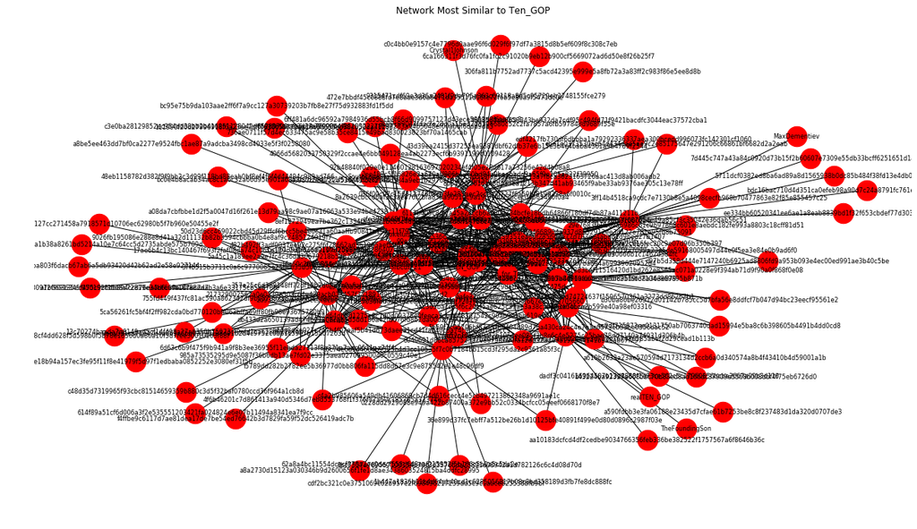

```python
pos = nx.spring_layout(g, iterations=10000)#nx.circular_layout(g)# iterations=1000)
nx.draw(g, pos, with_labels=True, node_size=700, font_size=8)
plt.rcParams["figure.figsize"] = [16,9]
#plt.figure(figsize=(10,12))
plt.title("Network Most Similar to Ten_GOP")
plt.savefig('Ten_GOP.png', dpi=300)
plt.show()
```

```python
btw = nx.current_flow_betweenness_centrality(g)
for_plot = sorted(btw.items(), key=lambda kv: kv[1], reverse=True)[0:15]
for_plot
```

```
[('c6c74e6d944604b9525b4d3cc10535f7c0b7184bb15cd3f295da2c9361a85f3c',
  0.17038406246812318),
 ('37fb515b3711c0a6c9770065e25dcb35b50b7283e4db14a505a345e3fbcdf221',
  0.15556254953473392),
 ('d2857a1f930016f6118ec3d00058b9ff687b54e49a85cf3c35042e36dab56c51',
  0.15120579460162634),
 ('LaChristie', 0.13726044666755596),
 ('217329002562a0e0a39e503c64e429acb013457f34189199b1e301bb6f2e97d2',
  0.1343627188995848),
 ('b57c1fec780af2b1064ee085f3b8c6c4e5275c25bae78dd7140a74931d306b4b',
  0.13046472188782265),
 ('8ef1372949ea7be362c1334fa45071bcb3c4db56a4ebaf12d6ff19756c48c9d9',
  0.13043026929399817),
 ('036f00c07c156312746b8cb3fe285aec2ccf360227f6a59bf8199238a6f0010c',
  0.11732525259447488),
 ('2ee489c5f16826e2a670aff886b1260bd84a9baabbdc9a65f9e105a822f39950',
  0.11101114218120804),
 ('BlackToLive', 0.08746766916589657),
 ('Pamela_Moore13', 0.08238544655759027),
 ('wokeluisa', 0.0806067172678536),
 ('51d25030fad3764e2c64a279800b0f7207fb2c063c796504f667e8a1e3705660',
  0.07838635909551765),
 ('0bbce9c98c4496cd179c5dc995b8d96aaa4e9de5bc2519fc7104e869895b871b',
  0.07650417171256134),
 ('16c60c26f0005dd6e0814ffa8972726649ea075f748c0253691ee53d05dde56e',
  0.07607956968817482)]
```

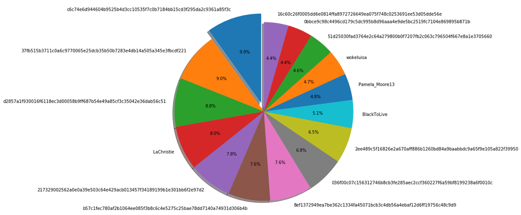

```python
labels = []
values = []
for i in range(0, len(for_plot)):
    labels.append(for_plot[i][0])
    values.append(for_plot[i][1])
#x,y = zip(for_plot)
fig1, ax1 = plt.subplots()
explode = list()
for val in values:
    if(val != max(values)):
        explode.append(0)
    else:
        explode.append(0.1)
ax1.pie(values, explode=explode, labels = labels, autopct='%1.1f%%', shadow=True, startangle=90)
ax1.axis('equal')
#plt.plot(labels,values)
#plt.plot(for_plot)
plt.rcParams["figure.figsize"] = [12,9]
plt.show()
```

**Networks based on a Word**

What does the network of people most similar to the term `republican` look like?

```python
def buildWordNetwork(term, numUsers,columns, u=np.genfromtxt("u.csv", delimiter=','),
                     v=np.genfromtxt("v.csv", delimiter=','),
                    s=np.genfromtxt("s.csv", delimiter=','),
                    users = pd.read_csv("users.csv"),
                    network = nx.Graph()):
    nodes = wordToAllUsers(u,s,v, term, columns, numUsers, users)
    sn = nodes[0][0]
    for edge in nodes:
        network.add_edge(sn, edge[0], weight=edge[1])
        secondaryNodes = userToAll(v,s, edge[0], numUsers, users)
        for sec in secondaryNodes:
            network.add_edge(edge[0], sec[0], weight=sec[1])
    return(network)
```

```python
n = buildWordNetwork("republican", 15, columns, u, v, s, users)
```

```python
for node in n.nodes():
    print(node)
```

```
bdb525726504a0e82cda02a42608c088ba56e5f39159145dd2fad907d4ceb5d0
9d6cca646e3e183e27cac59242186f578e0d515338da99d75877e3acd69425e2
959d95055b6bc65ab3a8ccef85db461f36b8e7df3630780abf97e1f2415d903b
105f376690d717af2c860c019fa3b2d093c094b935b3defff91384345fd1a301
3c25dbcab79d1f51dfb33d807c4f899ad3e293a524bbe336884b882930084baf
3fa2180cdd4b149f360c0cff2224f5bc629d485e732244bddfa28ace16ec7ed2
81895eb7ecb2acfaea3f407b253c60fc015613a0e975e7154e449a800e7e074f
36b7c2d1c11606c75ede9e19acd0e36f9386fc84a835c14e13f153579cee334b
fa1901deb376e24b35dfc72ac035b3ea53795f9faf86e8be07bff4fd1b84740d
249064136b1c5cb00a705316ab73dd9b53785748ab757f02df7e7a9876906139
8ba02fd3aed56f9a56f1ae834e686a55be914d2557711c8ebb5f6f4024255a8d
c8fe771b16bf26afae40b1ef218fa044d2ce85cd6ff56e7dda23529b5ac37976
9a6afc0bf51e3e22ee1b11bdffc5ebddc75aca10a916131b91d451aa14d3a7b6
93039346fb706a39d165ca9ed352a842cb8485a631238e08413666c9b76b1f7a
f556a62f676383e6c9a53fa549f52907edc2c8bcca091602cba120543a15c75a
b20786822be5f07949706b899ffbe8974467324810dca9efa7429b61832ed518
16329fa4bf35d298ed8f8e4ec4126e939dd312dde084798f7c63e928179dc575
17e124ac4ca93f89481de3001a4c73fab2d786ffa5fa4445a6ce6a2b87fb3a61
ecbf6f8cd4ac98ccbc37048ebe2ad8c81bec71283a2fa6e75a4248de75955858
c0b654986ecdf566e1c2b3e5d6ef113358a950c49ed2d53cb55b0de9eaf1f421
2e53be78d33abaff627fc091e0317b2a030935496e0ae80cf116faa51ae93d4d
a4746268702db4284bc6a181832b74150ff5afe77c0e369d72f03f1029d8664b
5e832f9b18956651be452a51a64d390af15027f4da6fd2279315d12fc37f011b
7f735fa27e8378f1418559370e6342b307a1b38e227b0e41df881d17f91a290b
757d12dfc934920c3d20525e82ba7adffaf710f81df68b0a076c5ce48b03f803
e0453cc56894f0c009f4ab308adc28a9f4fa25a4c3882579d99693aa09ac9774
99c3c00b9aa6dbe49d32a0d71a8f94b907c6e01caaa84a7cfabfd5696625c03a
637d818c682df7542a23f63ec365c69ed9c1c7524e3573923cbd939b3180231c
73f2ed562697f340f4e3ef8b7b248271317662f335b5776b37ac4bcecdf87306
037f351a4dd5fcc1c46144caca0fb7b6c63806f3c97372650d45f159c5a7c13a
437ab16e527f561f9c0e9c6a642b81903f86e5f90ae3e8aa5af43666a03e349e
3ac5b0bdb92cd4ab27c8053dbe51fedd43539204f164333365ee5383538f326e
856bb95e677545d561b76c6142e37197da9ee37f4fceb21bd454474273b53614
3065ff91d22408dce34750d137a717d49b8c1d62ca07fee349c39a97a86a9b1a
bcd69ddcdfb29713da3ed1a3dc7bfd7fcc1ac331025a96ff52cc936534463124
1bc8fb98ab379d63a2279d31446e2746a7ce18a73bd900e59698b8bb9f1df424
4dc4f9360437c779e3a5b85b96681af17d4748f121cb3ec9b3b055e3988ad264
30685b26c59a26a1ecb953413037370ebc3275be74ade120d96f3f5e326cedf7
d89a62e4f39abdecb82c5c5767ab1de8a48c0fe6c2134b8db421ac2267d62e3e
4ce989327c4d6317918452ca868be2b9e7363bfdb80ea8630ac06c1690ca80e9
```

[output cut: 78 more lines]

```
Seattle_Post
OaklandOnline
DetroitDailyNew
ef2244f492e220412d27ad6b0a8a70f2de78cdff0194899d5a9e64d19aa3fcc9
9ab87d3f25c65df8aa6c8281b258405b9170a19c3a2c65536220e0085c1a6515
2b17ba0e0abba25ac01569a56018d986985494d4e20f402736b667fbbcc48cbc
ba1e97a97132ad86427c11e30fcf9585ab252cfd77f2639ec0e45ca4e296fa3f
c553a06deb41885efcdf9d62279deb39a9aafee921dd37124b207f794ab67d42
4fafd6c9eda98e177bf5df6f003851cbf59f22628766af513b106196621b439d
6e71312bce02413479b1d33d1de5e5efba6489ab6fe76bdaeec5b2c296cb43a9
080da9e6b0c293d8e7abe6115605790ec8bc9a5c75a2b3e60539e67e3f100875
4a691128580fe9becb8d8d095f5ce1420b3661226736f12262016e3ff1c34750
5e4157702eb2a6214919d23416f42894b6ff3aac4ad1c5bd76b53e165763ee75
bc0bbc29ffa127d47b0f9edcb9955a90e662aca6f165d4cb552c9f8905ce0545
7226285d12785bc40c739926d3a615608f07716d59144b28771b2906f114f34d
```

```python
for edge in n.edges():
    print(edge)
```

```
('bdb525726504a0e82cda02a42608c088ba56e5f39159145dd2fad907d4ceb5d0', 'bdb525726504a0e82cda02a42608c088ba56e5f39159145dd2fad907d4ceb5d0')
('bdb525726504a0e82cda02a42608c088ba56e5f39159145dd2fad907d4ceb5d0', '9d6cca646e3e183e27cac59242186f578e0d515338da99d75877e3acd69425e2')
('bdb525726504a0e82cda02a42608c088ba56e5f39159145dd2fad907d4ceb5d0', '959d95055b6bc65ab3a8ccef85db461f36b8e7df3630780abf97e1f2415d903b')
('bdb525726504a0e82cda02a42608c088ba56e5f39159145dd2fad907d4ceb5d0', '105f376690d717af2c860c019fa3b2d093c094b935b3defff91384345fd1a301')
('bdb525726504a0e82cda02a42608c088ba56e5f39159145dd2fad907d4ceb5d0', '3c25dbcab79d1f51dfb33d807c4f899ad3e293a524bbe336884b882930084baf')
('bdb525726504a0e82cda02a42608c088ba56e5f39159145dd2fad907d4ceb5d0', '3fa2180cdd4b149f360c0cff2224f5bc629d485e732244bddfa28ace16ec7ed2')
('bdb525726504a0e82cda02a42608c088ba56e5f39159145dd2fad907d4ceb5d0', '81895eb7ecb2acfaea3f407b253c60fc015613a0e975e7154e449a800e7e074f')
('bdb525726504a0e82cda02a42608c088ba56e5f39159145dd2fad907d4ceb5d0', '36b7c2d1c11606c75ede9e19acd0e36f9386fc84a835c14e13f153579cee334b')
('bdb525726504a0e82cda02a42608c088ba56e5f39159145dd2fad907d4ceb5d0', 'fa1901deb376e24b35dfc72ac035b3ea53795f9faf86e8be07bff4fd1b84740d')
('bdb525726504a0e82cda02a42608c088ba56e5f39159145dd2fad907d4ceb5d0', '249064136b1c5cb00a705316ab73dd9b53785748ab757f02df7e7a9876906139')
('bdb525726504a0e82cda02a42608c088ba56e5f39159145dd2fad907d4ceb5d0', '8ba02fd3aed56f9a56f1ae834e686a55be914d2557711c8ebb5f6f4024255a8d')
('bdb525726504a0e82cda02a42608c088ba56e5f39159145dd2fad907d4ceb5d0', 'c8fe771b16bf26afae40b1ef218fa044d2ce85cd6ff56e7dda23529b5ac37976')
('bdb525726504a0e82cda02a42608c088ba56e5f39159145dd2fad907d4ceb5d0', '9a6afc0bf51e3e22ee1b11bdffc5ebddc75aca10a916131b91d451aa14d3a7b6')
('bdb525726504a0e82cda02a42608c088ba56e5f39159145dd2fad907d4ceb5d0', '93039346fb706a39d165ca9ed352a842cb8485a631238e08413666c9b76b1f7a')
('bdb525726504a0e82cda02a42608c088ba56e5f39159145dd2fad907d4ceb5d0', 'f556a62f676383e6c9a53fa549f52907edc2c8bcca091602cba120543a15c75a')
('bdb525726504a0e82cda02a42608c088ba56e5f39159145dd2fad907d4ceb5d0', 'b20786822be5f07949706b899ffbe8974467324810dca9efa7429b61832ed518')
('bdb525726504a0e82cda02a42608c088ba56e5f39159145dd2fad907d4ceb5d0', 'ecbf6f8cd4ac98ccbc37048ebe2ad8c81bec71283a2fa6e75a4248de75955858')
('bdb525726504a0e82cda02a42608c088ba56e5f39159145dd2fad907d4ceb5d0', '037f351a4dd5fcc1c46144caca0fb7b6c63806f3c97372650d45f159c5a7c13a')
('bdb525726504a0e82cda02a42608c088ba56e5f39159145dd2fad907d4ceb5d0', '0cc46b0afa366843ec813e21793a9bdd651d1b0e2611f241a64210665cb0df0b')
('bdb525726504a0e82cda02a42608c088ba56e5f39159145dd2fad907d4ceb5d0', '5577e296af1dcbd8a879ae11bc5ed9cd9971eb2b079724aed3821496f92d169d')
('bdb525726504a0e82cda02a42608c088ba56e5f39159145dd2fad907d4ceb5d0', '2f35cf446715d94f5437232540bbcb9eb9057fcfce677786888cac2806cfa9b7')
('bdb525726504a0e82cda02a42608c088ba56e5f39159145dd2fad907d4ceb5d0', '437ab16e527f561f9c0e9c6a642b81903f86e5f90ae3e8aa5af43666a03e349e')
('bdb525726504a0e82cda02a42608c088ba56e5f39159145dd2fad907d4ceb5d0', 'dcf41049208eed29f0c4794a4823a6d9c1808a8bc3c5cae595032c449170dab6')
('bdb525726504a0e82cda02a42608c088ba56e5f39159145dd2fad907d4ceb5d0', '1e97dae1559f2dbbeeec28c36953b8b79ec7de9af898d06911cee1587061a582')
('bdb525726504a0e82cda02a42608c088ba56e5f39159145dd2fad907d4ceb5d0', 'TodayPittsburgh')
('bdb525726504a0e82cda02a42608c088ba56e5f39159145dd2fad907d4ceb5d0', '30b4299a0af0975117aa5f12af90810eca5358f72135e9fa939e1f14feafc248')
('9d6cca646e3e183e27cac59242186f578e0d515338da99d75877e3acd69425e2', '959d95055b6bc65ab3a8ccef85db461f36b8e7df3630780abf97e1f2415d903b')
('9d6cca646e3e183e27cac59242186f578e0d515338da99d75877e3acd69425e2', '105f376690d717af2c860c019fa3b2d093c094b935b3defff91384345fd1a301')
('9d6cca646e3e183e27cac59242186f578e0d515338da99d75877e3acd69425e2', '3fa2180cdd4b149f360c0cff2224f5bc629d485e732244bddfa28ace16ec7ed2')
('9d6cca646e3e183e27cac59242186f578e0d515338da99d75877e3acd69425e2', '81895eb7ecb2acfaea3f407b253c60fc015613a0e975e7154e449a800e7e074f')
('9d6cca646e3e183e27cac59242186f578e0d515338da99d75877e3acd69425e2', 'fa1901deb376e24b35dfc72ac035b3ea53795f9faf86e8be07bff4fd1b84740d')
('9d6cca646e3e183e27cac59242186f578e0d515338da99d75877e3acd69425e2', '3c25dbcab79d1f51dfb33d807c4f899ad3e293a524bbe336884b882930084baf')
('9d6cca646e3e183e27cac59242186f578e0d515338da99d75877e3acd69425e2', '249064136b1c5cb00a705316ab73dd9b53785748ab757f02df7e7a9876906139')
('9d6cca646e3e183e27cac59242186f578e0d515338da99d75877e3acd69425e2', '8ba02fd3aed56f9a56f1ae834e686a55be914d2557711c8ebb5f6f4024255a8d')
('9d6cca646e3e183e27cac59242186f578e0d515338da99d75877e3acd69425e2', 'c8fe771b16bf26afae40b1ef218fa044d2ce85cd6ff56e7dda23529b5ac37976')
('9d6cca646e3e183e27cac59242186f578e0d515338da99d75877e3acd69425e2', '93039346fb706a39d165ca9ed352a842cb8485a631238e08413666c9b76b1f7a')
('9d6cca646e3e183e27cac59242186f578e0d515338da99d75877e3acd69425e2', '9a6afc0bf51e3e22ee1b11bdffc5ebddc75aca10a916131b91d451aa14d3a7b6')
('9d6cca646e3e183e27cac59242186f578e0d515338da99d75877e3acd69425e2', '36b7c2d1c11606c75ede9e19acd0e36f9386fc84a835c14e13f153579cee334b')
('9d6cca646e3e183e27cac59242186f578e0d515338da99d75877e3acd69425e2', '16329fa4bf35d298ed8f8e4ec4126e939dd312dde084798f7c63e928179dc575')
('9d6cca646e3e183e27cac59242186f578e0d515338da99d75877e3acd69425e2', '17e124ac4ca93f89481de3001a4c73fab2d786ffa5fa4445a6ce6a2b87fb3a61')
```

[output cut: 171 more lines]

```
('1e97dae1559f2dbbeeec28c36953b8b79ec7de9af898d06911cee1587061a582', '6860403d52a7b1d54d36839a528376d0ec3cede28bbb8b8bb26cea2e3044a428')
('1e97dae1559f2dbbeeec28c36953b8b79ec7de9af898d06911cee1587061a582', 'ac79ec7bc02d21d996fc2437a585188deeba28a8f56562147b3ff098ea33e4e1')
('TodayPittsburgh', 'HoustonTopNews')
('TodayPittsburgh', 'fea5e166786f00c893ee247a87ab6047e3ed8727dbe4b5a67b64484dc777b070')
('TodayPittsburgh', 'KansasDailyNews')
('TodayPittsburgh', 'DallasTopNews')
('TodayPittsburgh', 'PhoenixDailyNew')
('TodayPittsburgh', 'NewOrleansON')
('TodayPittsburgh', '9848c409239da9dfaf5479925daaa8fb4c9dbe55ce19a19d4bb0dad8d8632578')
('TodayPittsburgh', 'DailySanFran')
('TodayPittsburgh', 'WashingtOnline')
('TodayPittsburgh', '750b53f9e9a6fbb92d9a635327001f6ca9f3acef7966a6d6f640e7031706d247')
('TodayPittsburgh', 'Seattle_Post')
('TodayPittsburgh', 'OaklandOnline')
('TodayPittsburgh', 'DetroitDailyNew')
```

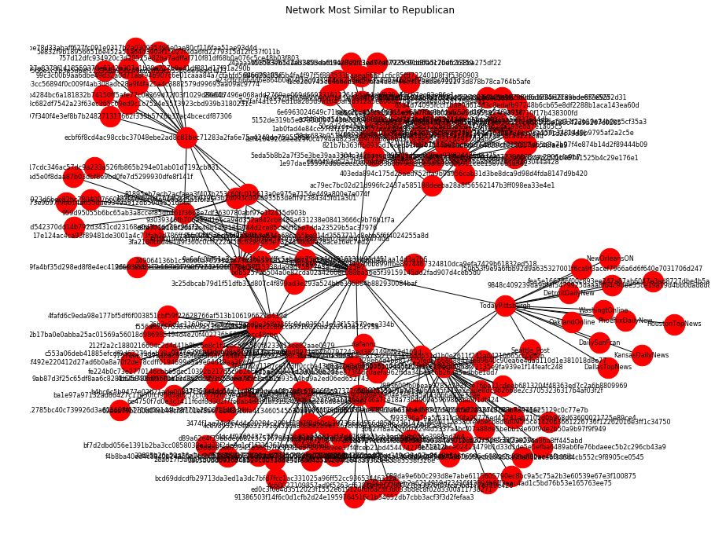

```python
pos = nx.spring_layout(n, iterations=10000)#nx.circular_layout(n)# iterations=1000)
nx.draw(n, pos, with_labels=True, node_size=700, font_size=8)
plt.rcParams["figure.figsize"] = [12,9]
#plt.figure(figsize=(10,12))
plt.title("Network Most Similar to Republican")
plt.savefig('republican.png', dpi=300)
plt.show()
```